# Dyfamed cruise before and during deployement of Argo float lovapm016a and lovapm016b

# Results

## Data

[output not shown]

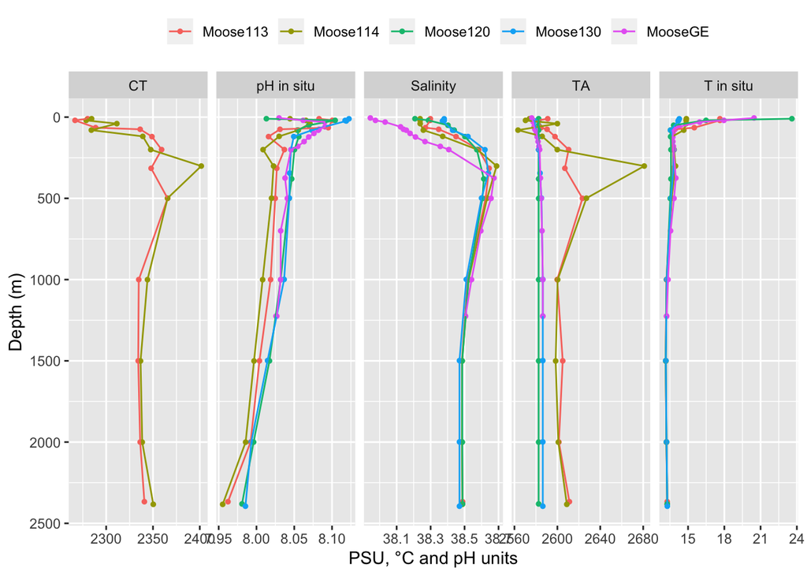

## MOOSE 113 and 114

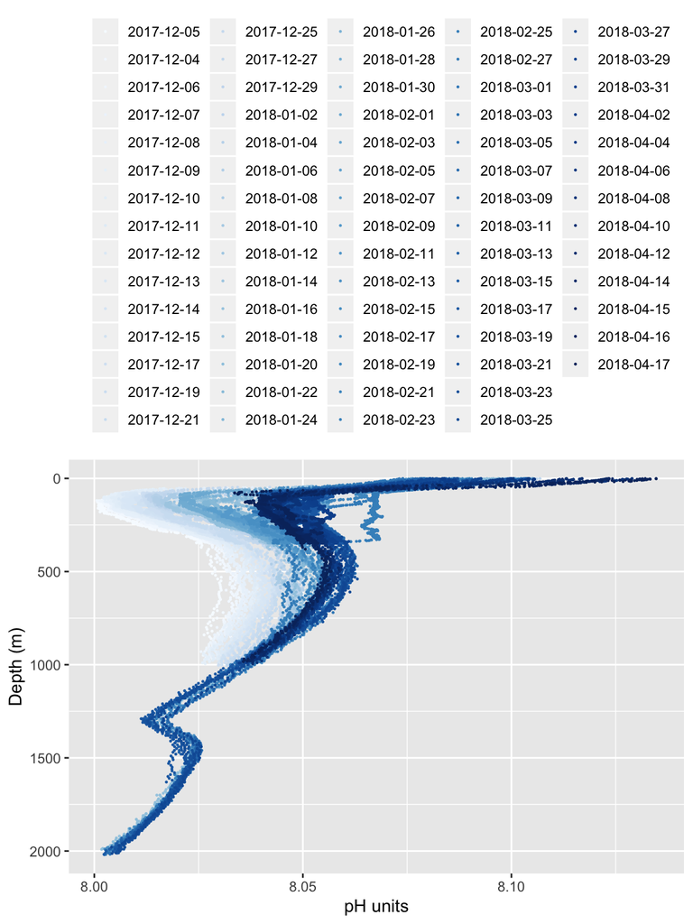

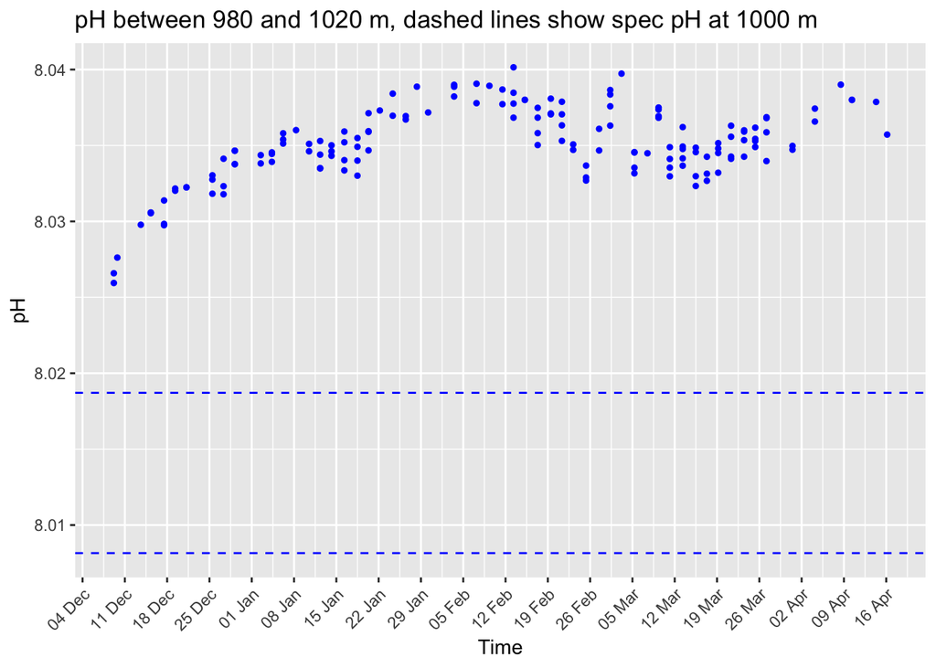

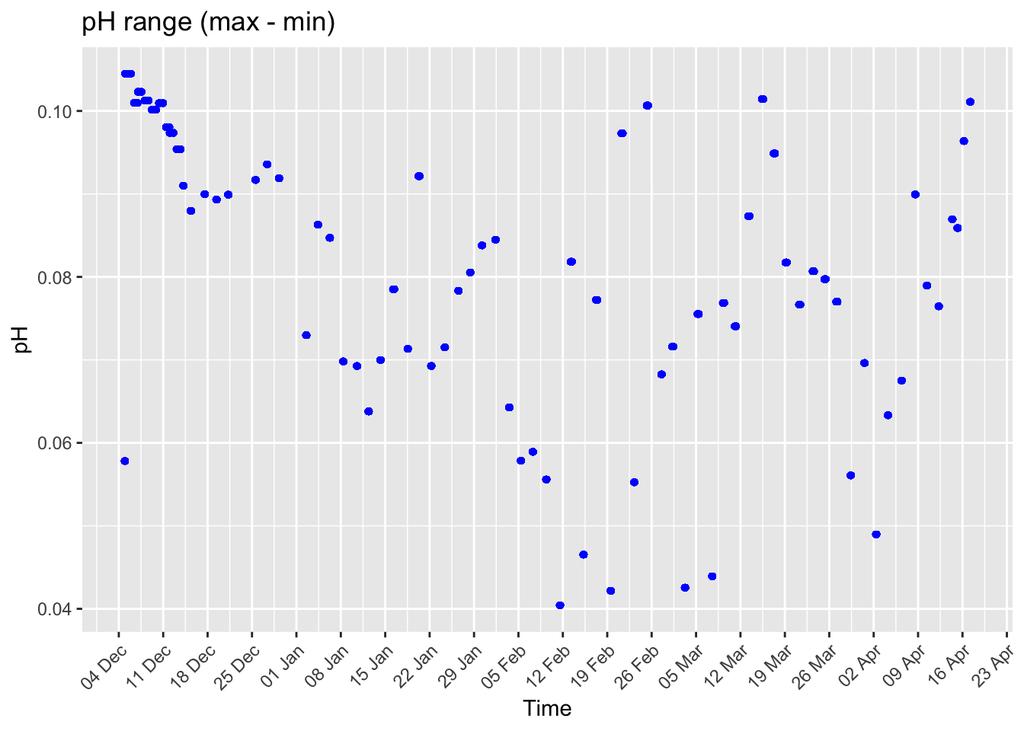

In the figure below, the depth distribution of pHT is shown. The error bars are standard deviations of 3 or 4 replicate measurements performed on the same sampling bottle.

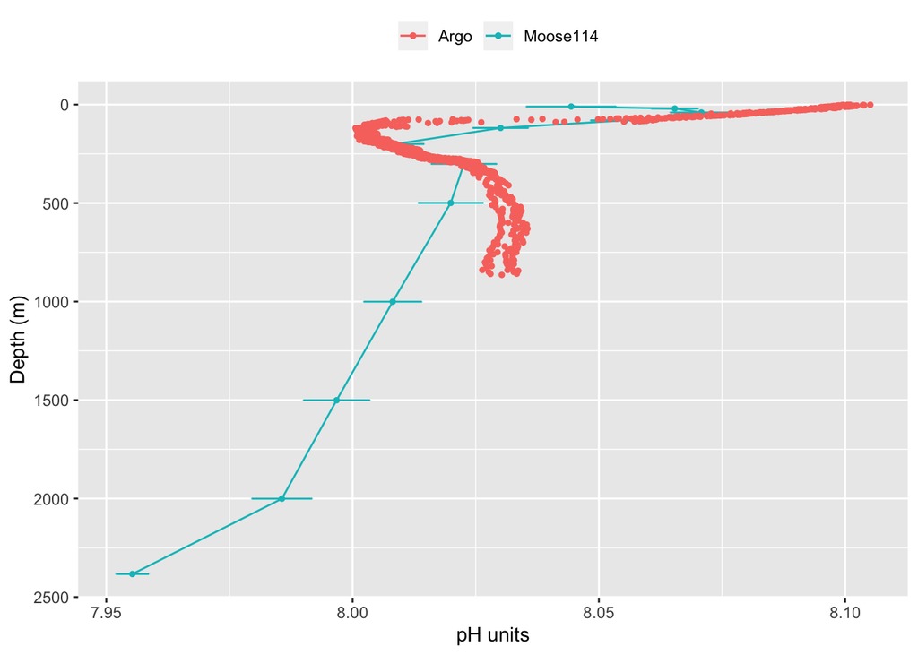

## MOOSE 120

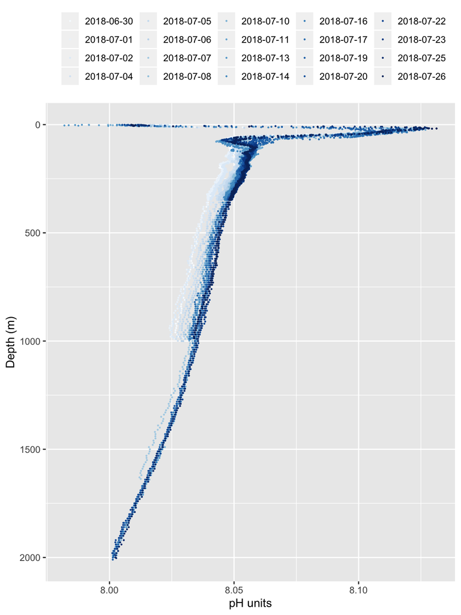

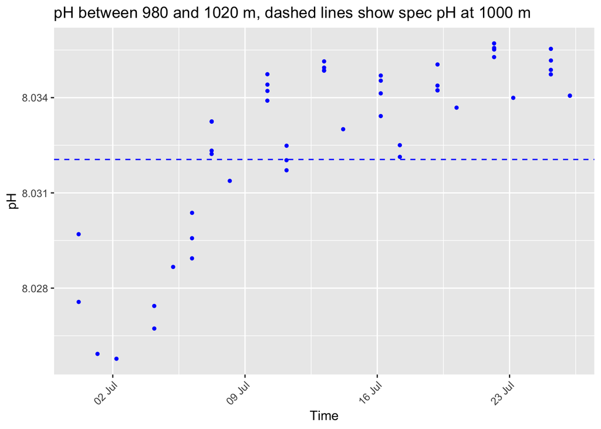

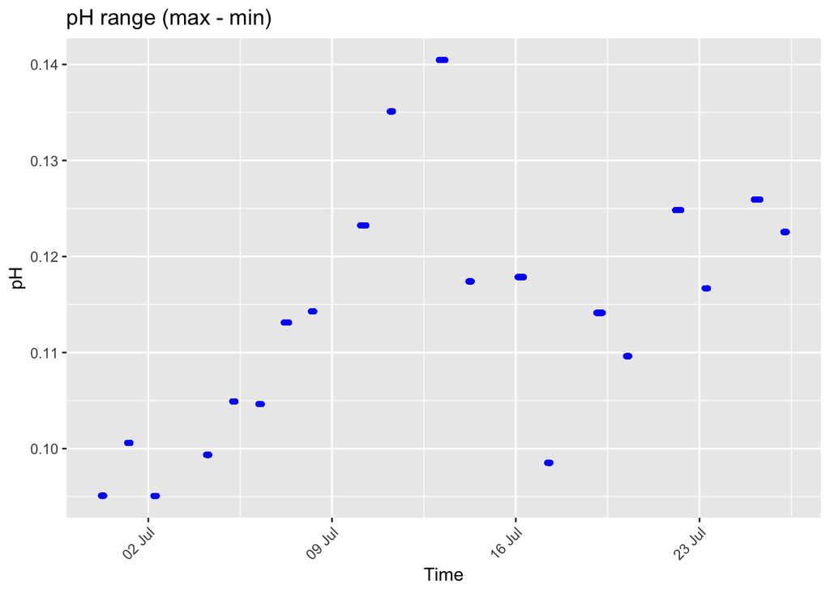

In the figure below, the depth distribution of pHT is shown. The error bars are standard deviations of 3 or 4 replicate measurements performed on the same sampling bottle.

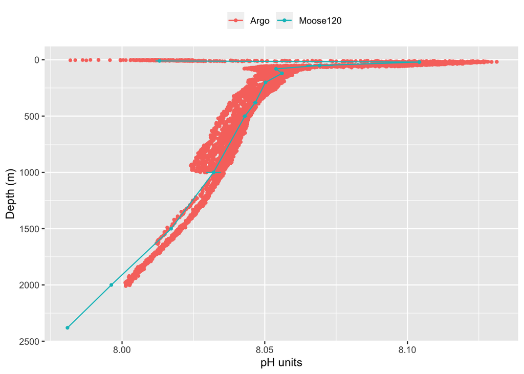

## MOOSE 130 et MOOSE GE

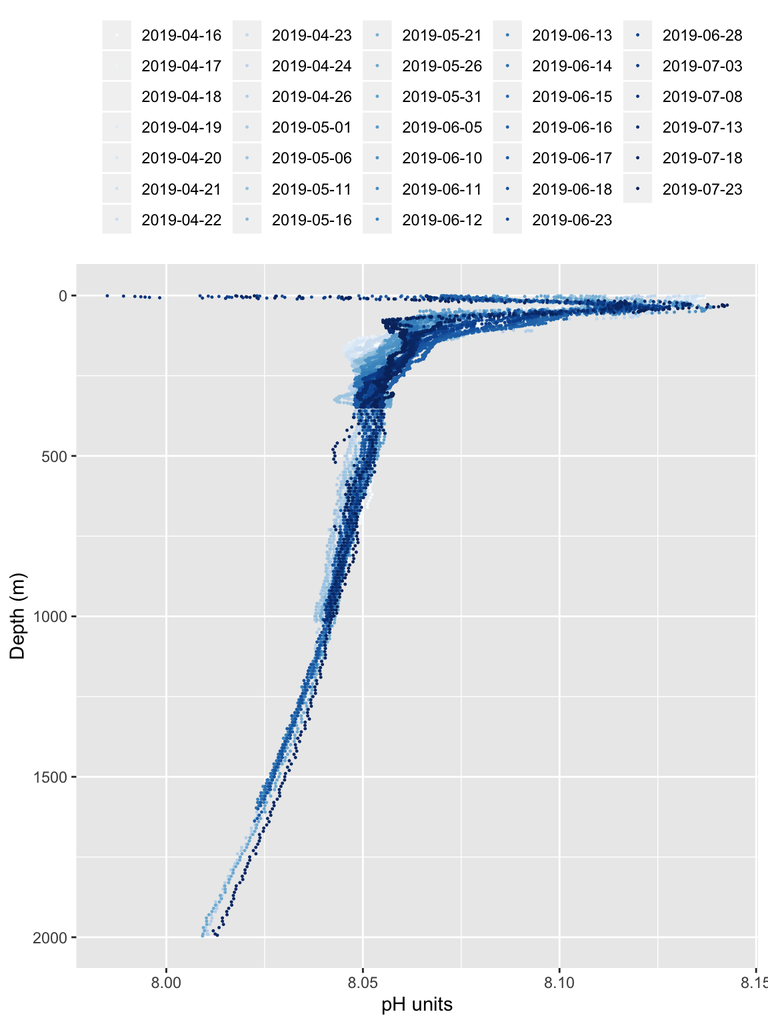

In the figure below, the difference is calculated using the Moose 130 spec pH profile before 18 June 2019 and using the Moose GE profile after that date.

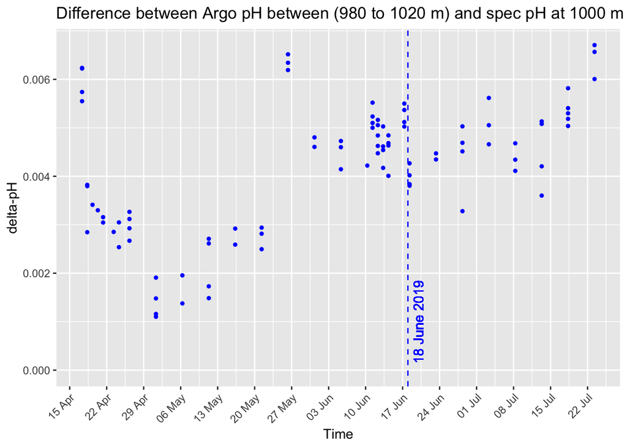

In the figure below, the depth distribution of pHT is shown. The error bars are standard deviations of 3 or 4 replicate measurements performed on the same sampling bottle.

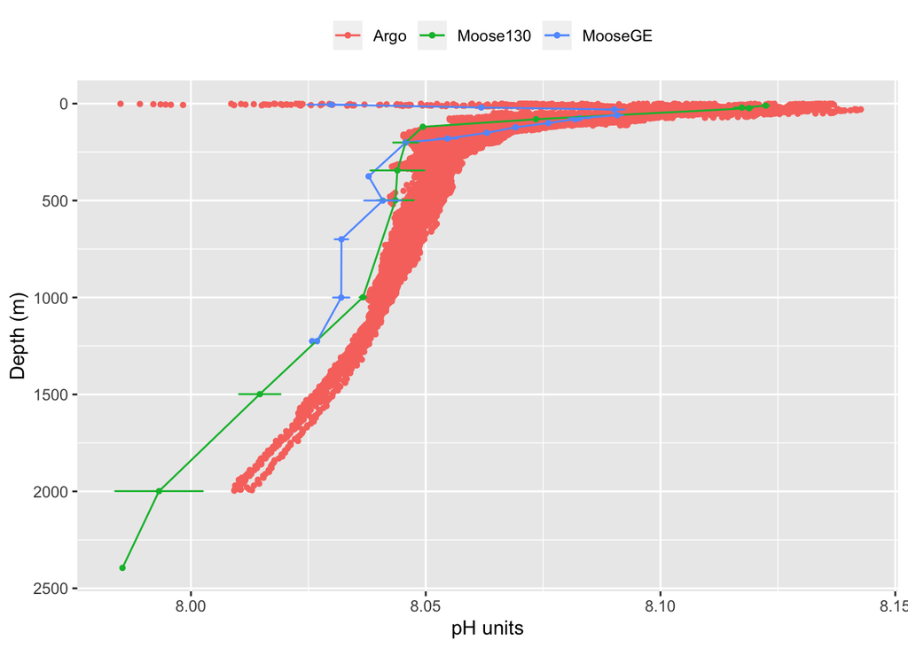

# Acknowledgements

Thanks are due to Laurent Coppola, Emilie Diamond, Melek Golbol, Eduardo Soto, Edouard Leymarie, Antoine Poteau and Catherine Schmechtig for assistance in the field and in the laboratory.

# References

Dickson A. G., Sabine C. L. & Christian J. R., 2007. Guide to best practices for ocean CO2 measurements. PICES Special Publication 3:1-191.

Gattuso J.-P., Epitalon J.-M., Lavigne H. & Orr J., 2017. seacarb: seawater carbonate chemistry. R package version 3.2.3. https://cran. r-project.org/package=seacarb.